[O’Hara on GitHub](https://github.com/oharac)

# Eco-Detectives: chapter 5

Compiled on Wed Jul 11 11:54:23 2018 by ohara

```r
knitr::opts_chunk$set(fig.width = 6, fig.height = 4, fig.path = 'Figs/',
                      echo = TRUE, message = FALSE, warning = FALSE)

source('https://raw.githubusercontent.com/oharac/src/master/R/common.R')
```

$\newcommand{\E}{\mathbb{E}}\newcommand{\Var}{\mathrm{Var}}$

# 1 Chapter 5: The Confrontation: Sum of Squares

## 1.1 5.1

First let’s set up a process model function based on eqn 5.1: $Y_i = A + BX_i + CX_i^2 + W_i$ where $W_i$ is process uncertainty.

```r
process_model <- function(x, a = 1, b = 1, c = 1, w = 1) {
  ### x can be a vector or a single number.
  ### w is the standard deviation for the process uncertainty (mean = 0)
  y <- a + b*x + c*x^2 + rnorm(n = length(x), mean = 0, sd = w)
  return(y)
}
```

Generate a vector of data based on the process model and plot it; let’s also run a linear model on it to see how close it comes on its own.

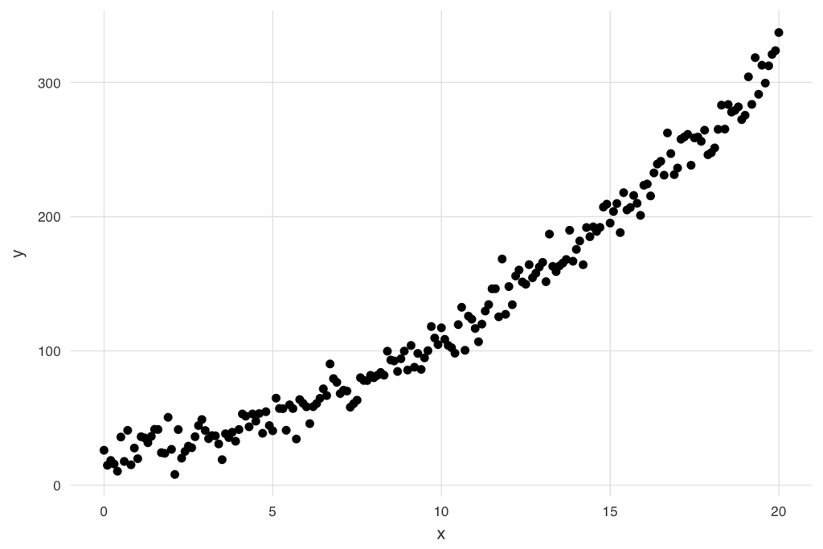

```r
a <- 21.2
b <- 2.9
c <- .6
w <- 10

a_vec <- seq(15, 25, .2)
b_vec <- seq(0, 5, .1)
c_vec <- seq(0, 1, .02)


x_vec <- seq(0, 20, .1)
y_vec <- process_model(x_vec, a, b, c, w)

lm_df <- data.frame(x = x_vec, y = y_vec) %>%
  mutate(x2 = x^2)

ggplot(lm_df, aes(x, y)) +
  ggtheme_plot() +
  geom_point()
```

```r
lm_check <- lm(y ~ x + x2, data = lm_df)
knitr::kable(summary(lm_check) %>% broom::tidy())
```

| term | estimate | std.error | statistic | p.value |
| --- | --- | --- | --- | --- |
| (Intercept) | 22.5549636 | 2.0881468 | 10.801426 | 0e+00 |
| x | 2.5159814 | 0.4823884 | 5.215675 | 5e-07 |
| x2 | 0.6136719 | 0.0233463 | 26.285629 | 0e+00 |

```r
lm_ests <- data.frame(method = c('actual value', 'lm()'),
                      a_est = c(a, lm_check$coefficients[1]),
                      b_est = c(b, lm_check$coefficients[2]),
                      c_est = c(c, lm_check$coefficients[3]))
```

Let’s set up a vector of values for each of A, B, and C. Presumably we have a decent guess about the neighborhood of each; otherwise if we end up finding our best value is on the edge of one of these ranges, we can extend the range and run it until the best values are all internal to the vectors.

Let’s also set up a function to do the sum of squares for a process model of known form (i.e. $A + BX + CX^2$) for a pair of vectors (x, y)

```r
ssr_fxn <- function(x_vec, y_vec, a_est, b_est, c_est) {
  ### This is pseudocode 5.1 number 3.  Using vectors we don't need to loop
  ### over all the y and x values; we can just calc the entire vector of
  ### differences and then add them up.
  ### Note: if you give it a vector of a, b, and/or c_ests, it will
  ### give unexpected results!

  y_est <- a_est + b_est * t(x_vec) + c_est * t(x_vec^2)

  ssr <- sum( (y_vec - y_est)^2 )

  return(ssr)

}
```

## 1.2 Analyze with for-loop

Using the function, we can do nested loops over each set of estimates. Time it, including creation of the vectors and array, to compare to data frame method.

```r
ptm <- system.time({

  L_array <- array(data = NA,
                   dim = c(length(a_vec), length(b_vec), length(c_vec)))

  for(i in seq_along(a_vec)) { # i <- 1
    a_est <- a_vec[i]

    for(j in seq_along(b_vec)) { # j <- 4
      ### for given value of a_est, loop over all possible b values
      b_est <- b_vec[j]

      for(k in seq_along(c_vec)) { # k <- 9
        ### for given value of a_est and b_est, loop over all possible c values
        c_est <- c_vec[k]


        ### For this set of values for a_est, b_est, and c_est, calculate
        ### the sum of squares and plug it into the array:
        L_array[i, j, k] <- ssr_fxn(x_vec, y_vec, a_est, b_est, c_est)

      } ### done with c vals for this value of a_est, b_est; exit and increment b_est
    } ### done with b vals for this value of a_est; exit and increment a_est
  } ### done deal

  ### Now we just find the location of the minimum value in the entire array, and
  ### figure out which values of a_est, b_est, and c_est go with that location.

  best_fit <- which(L_array == min(L_array), arr.ind = TRUE)

}) ### end of system.time call

cat(sprintf('Elapsed time for array size %s: %s sec\n', length(L_array), round(ptm[3], 3)))
```

Elapsed time for array size 132651: 1.828 sec

```r
loop_ests <- data.frame(method = 'for loop',
                        a_est = a_vec[best_fit[1]],
                        b_est = b_vec[best_fit[2]],
                        c_est = c_vec[best_fit[3]])

knitr::kable(bind_rows(lm_ests, loop_ests))
```

| method | a_est | b_est | c_est |
| --- | --- | --- | --- |
| actual value | 21.20000 | 2.900000 | 0.6000000 |
| lm() | 22.55496 | 2.515981 | 0.6136719 |
| for loop | 22.80000 | 2.400000 | 0.6200000 |

## 1.3 Analyze with dplyr::mutate

```r
ptm <- system.time({

  ests_df <- data.frame(a_est = rep(a_vec, times = length(b_vec) * length(c_vec)),
                     b_est = rep(b_vec, times = length(c_vec), each = length(a_vec)),
                     c_est = rep(c_vec, each = length(a_vec) * length(b_vec)))

  ### ssr should only get one value of a, b, c estimates; so use rowwise()
  ### to evaluate each row individually.  This kinda defeats the whole point
  ### of vectorization though!
  L_df <- ests_df %>%
    rowwise() %>%
    mutate(ssr = ssr_fxn(x_vec, y_vec, a_est, b_est, c_est)) %>%
    ungroup()

  best_fit_df <- L_df %>%
    filter(ssr == min(ssr))

}) ### end of system.time call

cat(sprintf('Elapsed time for dataframe size %s: %s sec\n', nrow(L_df), round(ptm[3], 3)))
```

Elapsed time for dataframe size 132651: 4.138 sec

```r
df_ests   <- data.frame(method = 'dplyr::mutate',
                        a_est = best_fit_df$a_est,
                        b_est = best_fit_df$b_est,
                        c_est = best_fit_df$c_est)

knitr::kable(bind_rows(lm_ests, df_ests))
```

| method | a_est | b_est | c_est |
| --- | --- | --- | --- |
| actual value | 21.20000 | 2.900000 | 0.6000000 |
| lm() | 22.55496 | 2.515981 | 0.6136719 |
| dplyr::mutate | 22.80000 | 2.400000 | 0.6200000 |

**NOTE:** The dataframe method is way slower here because I had to use `rowwise()` to calculate the ssr for each set of `a_est`, `b_est`, `c_est` - and `rowwise()` basically means it is no longer vectorized. Maybe this is where `purrr` comes in?

## 1.4 Analyze with `purrr`

```r
ptm <- system.time({

  ests_df <- data.frame(a_est = rep(a_vec, times = length(b_vec) * length(c_vec)),
                     b_est = rep(b_vec, times = length(c_vec), each = length(a_vec)),
                     c_est = rep(c_vec, each = length(a_vec) * length(b_vec)))

  L_df <- ests_df %>%
    mutate(ssr = purrr::pmap_dbl(ests_df, ~ ssr_fxn(x_vec = x_vec, y_vec = y_vec, ..1, ..2, ..3)))

  best_fit_df <- L_df %>%
    filter(ssr == min(ssr))

}) ### end of system.time call

cat(sprintf('Elapsed time for dataframe size %s: %s sec\n', nrow(L_df), round(ptm[3], 3)))
```

Elapsed time for dataframe size 132651: 1.874 sec

```r
map_ests  <- data.frame(method = 'purrr::map',
                        a_est = best_fit_df$a_est,
                        b_est = best_fit_df$b_est,
                        c_est = best_fit_df$c_est)

knitr::kable(bind_rows(lm_ests, map_ests))
```

| method | a_est | b_est | c_est |
| --- | --- | --- | --- |
| actual value | 21.20000 | 2.900000 | 0.6000000 |
| lm() | 22.55496 | 2.515981 | 0.6136719 |
| purrr::map | 22.80000 | 2.400000 | 0.6200000 |

`purrr::pmap` seems faster than `rowwise()` but still slower than a nested loop…

## 1.5 Analyze with `apply`

```r
ptm <- system.time({

  ests_mat <- matrix(c(rep(a_vec, times = length(b_vec) * length(c_vec)),
                       rep(b_vec, times = length(c_vec), each = length(a_vec)),
                       rep(c_vec, each = length(a_vec) * length(b_vec))),
                     ncol = 3)

  ssr <- apply(ests_mat, MARGIN = 1, FUN = function(x) {
        ssr_fxn(x_vec = x_vec, y_vec = y_vec, x[1], x[2], x[3])
      })

  best_fit_vec <- ests_mat[which(ssr == min(ssr)), ]

}) ### end of system.time call

cat(sprintf('Elapsed time for matrix size %s: %s sec\n', length(ests_mat), round(ptm[3], 3)))
```

Elapsed time for matrix size 397953: 1.953 sec

```r
apply_ests <- data.frame(method = 'base::apply',
                         a_est = best_fit_vec[1],
                         b_est = best_fit_vec[2],
                         c_est = best_fit_vec[3])

knitr::kable(bind_rows(lm_ests, apply_ests))
```

| method | a_est | b_est | c_est |
| --- | --- | --- | --- |
| actual value | 21.20000 | 2.900000 | 0.6000000 |
| lm() | 22.55496 | 2.515981 | 0.6136719 |
| base::apply | 22.80000 | 2.400000 | 0.6200000 |

`apply` should probably be faster than `purrr::map` but apparently not? anyway, in this particular instance, the nested for loops seem to be the winner!

## 1.6 With matrices

We can also get fancy and use some matrix magic:

$$\widehat{\mathbf{\beta}} = (\mathbf{X'X})^{-1}\mathbf{X'y}$$

where $\mathbf X$ is a matrix with columns for each parameter, including a column of 1s for the intercept.

```r
ptm <- system.time({
  X_mat <- data.frame(intcpt = 1,
                      x      = x_vec,
                      x_sq   = x_vec^2) %>%
    as.matrix() ### seems more straightforward to set it up this way...

  Xt_X <- t(X_mat) %*% X_mat
  Xt_y <- t(X_mat) %*% y_vec

  beta_hat <- solve(Xt_X) %*% Xt_y

}) ### end of system.time call

cat(sprintf('Elapsed time for matrix size %s: %s sec\n', length(X_mat), round(ptm[3], 3)))
```

Elapsed time for matrix size 603: 0.003 sec

```r
matrix_ests <- data.frame(method = 'matrix math',
                          a_est = beta_hat[1],
                          b_est = beta_hat[2],
                          c_est = beta_hat[3])

knitr::kable(bind_rows(lm_ests, matrix_ests))
```

| method | a_est | b_est | c_est |
| --- | --- | --- | --- |
| actual value | 21.20000 | 2.900000 | 0.6000000 |
| lm() | 22.55496 | 2.515981 | 0.6136719 |
| matrix math | 22.55496 | 2.515981 | 0.6136719 |

## 1.7 5.2

basically already incorporated into 5.1?

Let’s just run it again make it into a table of all the values, but with fewer X values.

```r
a <- 21.2
b <- 2.9
c <- .6
w <- 20

a_vec <- seq(15, 30, .2)
b_vec <- seq(0, 5, .1)
c_vec <- seq(0, 1, .02)


x_vec <- seq(0, 20, 1)
y_vec <- process_model(x_vec, a, b, c, w)

lm_df <- data.frame(x = x_vec, y = y_vec) %>%
  mutate(x2 = x^2)

lm_check <- lm(y ~ x + x2, data = lm_df)
knitr::kable(summary(lm_check) %>% broom::tidy())
```

| term | estimate | std.error | statistic | p.value |
| --- | --- | --- | --- | --- |
| (Intercept) | 8.2462386 | 11.8154493 | 0.697920 | 0.4941451 |
| x | 6.3895821 | 2.7377924 | 2.333845 | 0.0313965 |
| x2 | 0.4734252 | 0.1321613 | 3.582177 | 0.0021300 |

```r
lm_ests <- data.frame(method = c('actual value', 'lm()'),
                      a_est = c(a, lm_check$coefficients[1]),
                      b_est = c(b, lm_check$coefficients[2]),
                      c_est = c(c, lm_check$coefficients[3]))
```

```r
ptm <- system.time({

  L_array_small <- array(data = NA,
                   dim = c(length(a_vec), length(b_vec), length(c_vec)))

  for(i in seq_along(a_vec)) { # i <- 1
    a_est <- a_vec[i]

    for(j in seq_along(b_vec)) { # j <- 4
      ### for given value of a_est, loop over all possible b values
      b_est <- b_vec[j]

      for(k in seq_along(c_vec)) { # k <- 9
        ### for given value of a_est and b_est, loop over all possible c values
        c_est <- c_vec[k]


        ### For this set of values for a_est, b_est, and c_est, calculate
        ### the sum of squares and plug it into the array:
        L_array_small[i, j, k] <- ssr_fxn(x_vec, y_vec, a_est, b_est, c_est)

      } ### done with c vals for this value of a_est, b_est; exit and increment b_est
    } ### done with b vals for this value of a_est; exit and increment a_est
  } ### done deal

  ### Now we just find the location of the minimum value in the entire array, and
  ### figure out which values of a_est, b_est, and c_est go with that location.

  best_fit <- which(L_array_small == min(L_array_small), arr.ind = TRUE)

}) ### end of system.time call

cat(sprintf('Elapsed time for array size %s: %s sec\n', length(L_array_small), round(ptm[3], 3)))
```

Elapsed time for array size 197676: 1.644 sec

```r
a_est <- a_vec[best_fit[1]]
b_est <- b_vec[best_fit[2]]
c_est <- c_vec[best_fit[3]]

loop_ests <- data.frame(method = 'for loop',
                        a_est,
                        b_est,
                        c_est)

knitr::kable(bind_rows(lm_ests, loop_ests))
```

| method | a_est | b_est | c_est |
| --- | --- | --- | --- |
| actual value | 21.200000 | 2.900000 | 0.6000000 |
| lm() | 8.246239 | 6.389582 | 0.4734252 |
| for loop | 15.000000 | 4.900000 | 0.5400000 |

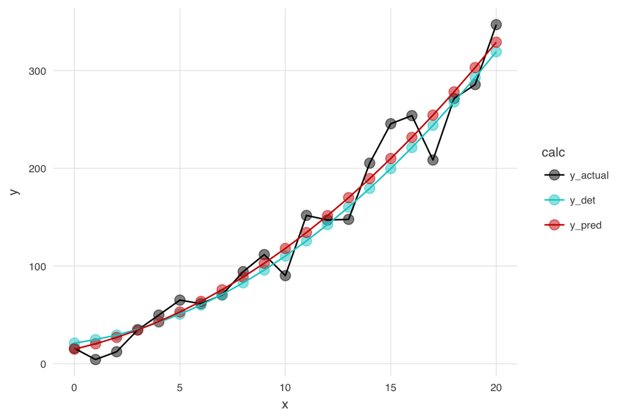

```r
vals_df <- data.frame(x = x_vec, y_actual = y_vec) %>%
  mutate(y_det = a + x*b + x^2 * c,
         y_pred = a_est + x * b_est + x^2 * c_est) %>%
  gather(calc, y, starts_with('y_'))

ggplot(vals_df, aes(x, y, color = calc)) +
  ggtheme_plot() +
  geom_point(size = 3, alpha = .5) +
  geom_line(aes(group = calc)) +
  scale_color_manual(values = c('black', 'cyan3', 'red3'))
```

## 1.8 Goodness of fit

Using the parameters from that last run, let’s check goodness of fit of each WRT the estimates of the other two.

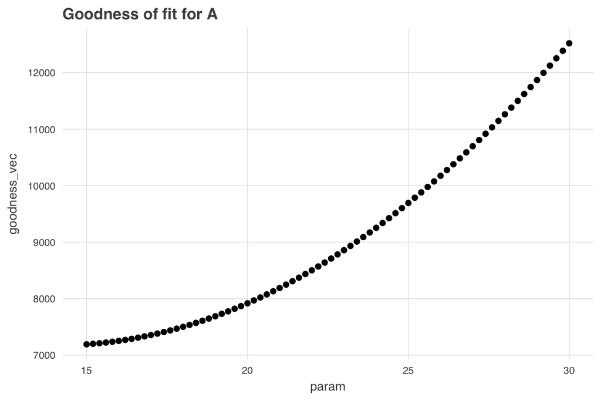

```r
goodness_vec <- vector('numeric', length = length(a_vec))
for (i in seq_along(a_vec)) {
  goodness_vec[i] <- ssr_fxn(x_vec, y_vec, a_vec[i], b_est, c_est)
}

goodness_df <- data.frame(param = a_vec, goodness = goodness_vec)
ggplot(goodness_df, aes(x = param, y = goodness_vec)) +
  ggtheme_plot() +
  geom_point() +
  labs(title = 'Goodness of fit for A')
```

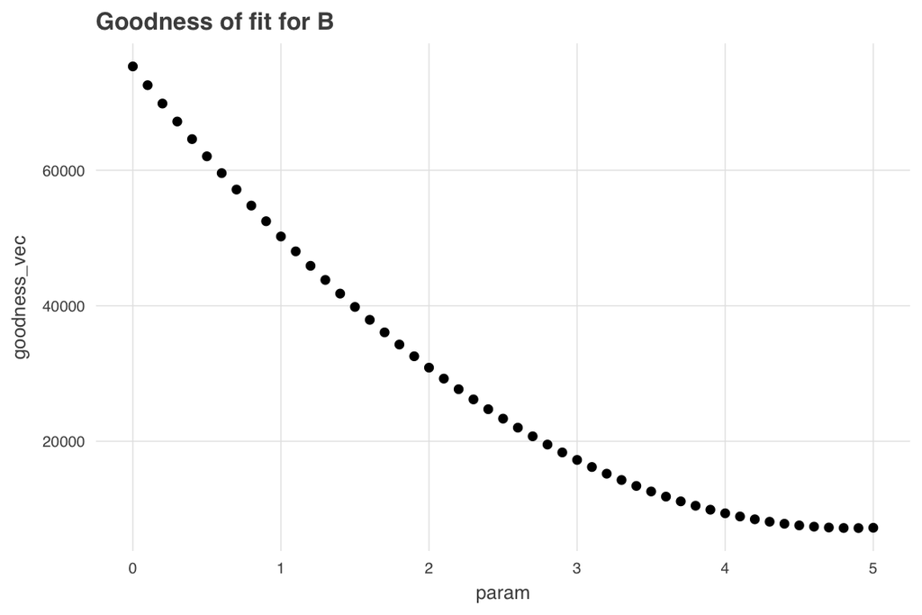

```r
goodness_vec <- vector('numeric', length = length(b_vec))
for (i in seq_along(b_vec)) {
  goodness_vec[i] <- ssr_fxn(x_vec, y_vec, a_est, b_vec[i], c_est)
}

goodness_df <- data.frame(param = b_vec, goodness = goodness_vec)
ggplot(goodness_df, aes(x = param, y = goodness_vec)) +
  ggtheme_plot() +
  geom_point() +
  labs(title = 'Goodness of fit for B')
```

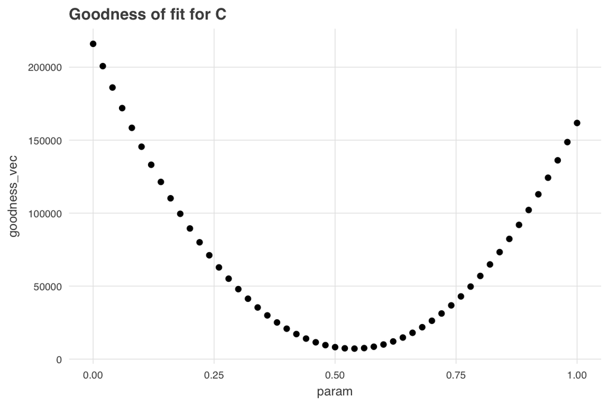

```r
goodness_vec <- vector('numeric', length = length(c_vec))
for (i in seq_along(c_vec)) {
  goodness_vec[i] <- ssr_fxn(x_vec, y_vec, a_est, b_est, c_vec[i])
}

goodness_df <- data.frame(param = c_vec, goodness = goodness_vec)
ggplot(goodness_df, aes(x = param, y = goodness_vec)) +
  ggtheme_plot() +
  geom_point() +
  labs(title = 'Goodness of fit for C')
```